# Intermediate Python for Engineers - Day 1

Welcome!

# Setup

Here are some setup instructions:

## Browser

Please use Chrome or Firefox or Safari. *Preferably not IE or Edge*.

## Jupyter notebook server

1. Go to https://hub.pythoncharmers.com/
2. Your username is your email address
3. The password is the same as you used to log in to Zulip and is in the setup email.

## Load up your notebook

- It will be called "Yourname Day 1.ipynb".
- Save it (Control-S or File | Save Notebook).

We'll give more instructions on getting started with the notebooks as we start the course.

## Zulip chat server

1. Go to https://pythoncharmers.zulipchat.com
2. **Test:** Please send a message to our stream (#**485 Python for Engineers** ) saying Hi!

## Resources

- Please download the course materials PDF (in your home folder)
- You may also download the `.zip` file containing the Jupyter Notebooks of the course materials

## Trainer notebook

We suggest that you load up the trainer's notebook from the Trainer folder in a separate browser tab and reload when needed.

(To do this, right-click the file, then choose "Open in New Browser Tab". Then hit F5 or Command-R whenever you want to see the latest version of the trainer's notebook.)

## Session 1: Intermediate language features

Session 1 will teach you about important features for maximizing your pro- ductivity with Python including classes and iterators:

- Files, bytes, strings, and encodings
- Classes and objects
- Named tuples. When (not) to use classes
- Initialization, data classes, class methods, inheritance • Properties, special methods
- Iterators and generators, with applications to large datasets; toolz

## Introductions!

2 things please:

- Your background
- Any particular requests for the course
- Ed Schofield: background in ML.
- Henry Walshaw: background in GIS, consulting.
- Henry: trader. Building tooling: more scalable / sustainable.
- Yunhao: quant. Working with Python daily to implement ideas, build prototypes for traders. Goal: write better Python code, use its features more effectively.
- Maciej: trading engineer. Build tools around pipelines. Utilities to support the infrastructure. Difficult to work with code. Goal: more scalable / sustainable. Also: interested in multithreading / multiprocessing.
- Rob: econometrics & CS. Building tools. Primary goal: More sustainable.
- Aneta: Software developer. Java primarily. Mind is in Java. Slows her down.
- Joery: background in software dev. Data engineer. Python 3 years. Goal: level up skills
- Laurens: IMC 2 years. BG: elec eng, CS, embedded systems. Hardware engineer with FPGAs. Elaborate testing f/work with Python. Goal: know more advanced features to leverage this framework.
- Panos: bg elec eng and CS. BI team: data analytics work. Goal: understand more features of Python, develop better coding practices.
- Marco: bg electronics engineering. Hardware engineer like Laurens. Goal: better understand other people's code at IMC. Also: build a better testing framework in the codebase.
- Faek: bg in network engineering. Recent at IMC. Goal: understand more of the IMC codebase in Python. Know the basics of Python.
- David: Bg in CS. S/ware eng. 1.5 years IMC. Seen a fair amount of Python, goal to refresh knowledge, easier, faster
- Laurent: bg in CS. S/ware eng execution team. Building low-latency trading system in IMC. Never learned Python properly. Goal: make better analysis tools that are maintainable, can be reused by traders.
- Rick: IMC 1.5 months. Software execution team. CS BG. Python here and there. Goal: reusable, maintainable, etc.
- Laena: background in CS. Work as a system engineer. Rusty in coding.

## Quick refresher about Python's types

```python
myname = 'Ed'
```

```python
type(myname)   # Shift-Enter or Control-Enter
```

```
str
```

```python
myname.upper?
```

```
Signature: myname.upper()
Docstring: Return a copy of the string converted to uppercase.
Type:      builtin_function_or_method
```

```python
myname.upper()
```

```
'ED'
```

```python
k = 3**1000
```

```python
k
```

```
132207081948080663689045525975214436596542203275214816766492…
```

```python
type(k)
```

```
int
```

```python
k.bit_length()
```

```
1585
```

```python
data = k.to_bytes(1600, 'little')
```

```python
type(data)
```

```
bytes
```

A `bytes` object is a sequence of integers.

```python
x = 1.5
```

```python
type(x)
```

```
float
```

a 64-bit IEEE double

```python
x.as_integer_ratio()
```

```
(3, 2)
```

### Container types

```python
weekdays = ('Mon', 'Tues', 'Wed', 'Thurs', 'Fri')
```

```python
type(weekdays)
```

```
tuple
```

- double
- triple
- quadruple
- quintuple
- ...
- $n$-tuple

Immutable:

- int
- float
- str
- tuple
- frozenset
- frozendict

Mutable:

- list
- set
- dict
- array (NumPy)
- dataframe (Pandas)

```python
days = list(weekdays)
```

```python
days
```

```
['Mon', 'Tues', 'Wed', 'Thurs', 'Fri']
```

```python
days.append('Sat')
```

```python
days.append('Sun')
```

```python
days
```

```
['Mon', 'Tues', 'Wed', 'Thurs', 'Fri', 'Sat', 'Sun']
```

```python
list.
```

[output not shown]

```python
heights_dict = {'Ed': 175, 'Henry': 173, 'Maciej': 190}
```

```python
type(heights_dict)
```

```
dict
```

```python
heights_dict['Ed']
```

```
175
```

In-place modification or adding a new key-value pair:

```python
heights_dict['Ed'] = 176
```

```python
heights_dict['Panos'] = 175
```

```python
heights_dict
```

```
{'Ed': 176, 'Henry': 173, 'Maciej': 190, 'Panos': 175}
```

Most important dict methods:

- keys
- values
- items

```python
heights_dict.keys()
```

```
dict_keys(['Ed', 'Henry', 'Maciej', 'Panos'])
```

```python
heights_dict.values()
```

```
dict_values([176, 173, 190, 175])
```

```python
heights_dict.items()
```

```
dict_items([('Ed', 176), ('Henry', 173), ('Maciej', 190), ('Panos', 175)])
```

```python
for name in heights_dict.keys():
    print(name)
```

```
Ed
Henry
Maciej
Panos
```

```python
for height in heights_dict.values():
    print(height)
```

```
176
173
190
175
```

#### Question: how stable are iterators?

In Python 3.5+ dictionaries have a stable order (based on insertion).

```python
for item in heights_dict.items():
    # Slow way:
    name = item[0]
    height = item[1]
    print(name, height)
```

```
Ed 176
Henry 173
Maciej 190
Panos 175
```

```python
# More elegant: use sequence unpacking
for name, height in heights_dict.items():
    print(name, height)
```

```
Ed 176
Henry 173
Maciej 190
Panos 175
```

### Another example

```python
import glob

filenames = glob.glob('/Data/*')
```

```python
from os.path import getsize
```

```python
sizes = []
for filename in filenames:
    sizes.append(getsize(filename))
```

```python
sizes
```

```
[6144,
 47978,
 95469,
 7152,
 7267422,
 2051665,
 4384,
 6671,
 8595854,
 15206,
 201127,
 223404,
 1310720,
 489445,
 9494,
 6144,
 5996512,
 6144,
 47260,
 138236,
 1675264,
 1353894,
 0,
 6144,
 8184,
 8361,
 3170,
 24769,
 12216,
 918960,
 5340,
 7339,
 2569728,
 71176,
 10875,
 11320,
 191968,
 615885,
 0,
 48168,
```

[output cut: 88 more lines]

```
 74703,
 72998,
 1076587,
 3082128,
 4096,
 6144,
 409456,
 11208,
 203798,
 37658,
 84921,
 549628,
 950,
 100059,
 3353]
```

Now, if you want to iterate through each file and use its size, you could do this:

#### Example: print out all files larger than 10 MB

```python
# Slow way:
for i in range(len(filenames)):
    filename = filenames[i]
    size = sizes[i]
    if size > 10**7:
        print(filename)
```

```
/Data/ASX2.h5
/Data/cites_1990.h5
```

```python
# Fast / elegant way:
for (filename, size) in zip(filenames, sizes):
    if size > 10**7:
        print(filename)
```

```
/Data/ASX2.h5
/Data/cites_1990.h5
```

```python
list(zip('ABC', 'DEFG'))
```

```
[('A', 'D'), ('B', 'E'), ('C', 'F')]
```

```python
zip?
```

```
Init signature: zip(self, /, *args, **kwargs)
Docstring:
zip(*iterables) --> A zip object yielding tuples until an input is exhausted.

   >>> list(zip('abcdefg', range(3), range(4)))
   [('a', 0, 0), ('b', 1, 1), ('c', 2, 2)]

The zip object yields n-length tuples, where n is the number of iterables
passed as positional arguments to zip().  The i-th element in every tuple
comes from the i-th iterable argument to zip().  This continues until the
shortest argument is exhausted.
Type:           type
Subclasses:
```

```python
from itertools import zip_longest
```

```python
list(zip_longest('ABC', 'DEFG', fillvalue=' '))
```

```
[('A', 'D'), ('B', 'E'), ('C', 'F'), (' ', 'G')]
```

## Files, bytes, strings and encodings

#### High-level way to read files: best practice: use the `pathlib` module

```python
from pathlib import Path
```

```python
zen_path = Path('/Data/zen.utf16.txt')
```

```python
zen_path
```

```
PosixPath('/Data/zen.utf16.txt')
```

```python
zen_path.exists()
```

```
True
```

```python
data = zen_path.read_bytes()
```

```python
type(data)
```

```
bytes
```

```python
data[:100]
```

```
b'\xff\xfeM0_0j0D0n0\x880\x8a0M0\x8c0D0j0\xb9eL0D0D0\n\x00\xff\xfe\n\x00\xff\xfeT0a0\x830T0a0\x830\xe3\x96W0D0n0\x880\x8a0\x010}v\xd2\x9eo0c0M0\x8a0W0f0\x8b0n0L0D0D0\n\x00\xff\xfe\n\x00\xff\xfe'
```

```python
text = zen_path.read_text(encoding='utf16')
```

```python
type(text)
```

```
str
```

```python
import this
```

```
The Zen of Python, by Tim Peters

Beautiful is better than ugly.
Explicit is better than implicit.
Simple is better than complex.
Complex is better than complicated.
Flat is better than nested.
Sparse is better than dense.
Readability counts.
Special cases aren't special enough to break the rules.
Although practicality beats purity.
Errors should never pass silently.
Unless explicitly silenced.
In the face of ambiguity, refuse the temptation to guess.
There should be one-- and preferably only one --obvious way to do it.
Although that way may not be obvious at first unless you're Dutch.
Now is better than never.
Although never is often better than *right* now.
If the implementation is hard to explain, it's a bad idea.
If the implementation is easy to explain, it may be a good idea.
Namespaces are one honking great idea -- let's do more of those!
```

```python
print(text)
```

```
きたないのよりきれいな方がいい

ごちゃごちゃ難しいのより、白黒はっきりしてるのがいい

めんどうなのよりかんたんな方がいい

けど、訳分かんなくなるくらいならめんどうな方がまし

ネストさせなくていいならしない方がいい

たくさん詰め込んだのよりスカスカな方がいい

読みやすさがたいせつなのよ

特別なこともあるけど掟破りってほどじゃない

実用性を求めてくと、ちょっとはずれちゃうこともあるけどね

わざとそうしてるんじゃない限り

エラーをだまって通すようなことがあっちゃいけません

あいまいなことをてきとーに処理しちゃいけません

間違えようのないやり方がひとつだけあるのがいいね

オランダ人以外には、ちょっと分かりにくかったりしてもね

やらないよりは今やるべき

けど今「すぐ」やるならやんない方がいいこともある

作るものをうまく説明できないようならそれはボツ

うまく説明できたらたぶんそれがグッド

ぶらぼーなアイディア名前空間、やっぱこれですね
```

#### Relationship between bytes and str:

```python
text == data.decode('utf16')
```

```
True
```

```python
text.encode('utf16') == data
```

```
True
```

```
          encode
    str ---------> bytes
    str <--------- bytes
          decode
```

### Example: cryptographic hashing

```python
import hashlib
```

```python
hasher = hashlib.md5(b'data goes here')   # pass a byte-string
hasher.hexdigest()
```

```
'9c48f2a4023ba27471a8fa259a000fa4'
```

### Quick exercise:

1. Write a function `get_hash(filename)` which returns the MD5 checksum for the given file's contents
2. Add a docstring to the function (the first string in the body of a function).
3. Test your function on some datasets in /Data: they should give the same result as the system `md5sum` tool.

```python
# Unix command:
!md5sum /Data/*.zip
```

```
d76232bbbaa1c5bfe6a1079528d62f3d  /Data/baby-names.csv.zip
ded479abb64c09f48b48ceb135fa80ac  /Data/patents.zip
9cfdb2f0318a81bcfed3f19fbb5fad87  /Data/USStatesData.zip
dba4ad1d2108bb708a53f622c5f0900a  /Data/WindowsLogs.zip
```

#### Solution

```python
from pathlib import Path
```

```python
def get_hash(filename):
    """Read the given file's contents and return the MD5 checksum.

    If the file doesn't exist, raise an exception.
    """
    path = Path(filename)
    data = path.read_bytes()
    hasher = hashlib.md5(data)   # pass a byte-string
    return hasher.hexdigest()
```

```python
get_hash('/Data/zen.utf16.txt')
```

```
'40836c03a1a2ab405710c52249137392'
```

```python
!md5sum /Data/zen.utf16.txt
```

```
40836c03a1a2ab405710c52249137392  /Data/zen.utf16.txt
```

```python
zipfiles = glob.glob('/Data/*.zip')
```

```python
zipfiles
```

```
['/Data/patents.zip',
 '/Data/baby-names.csv.zip',
 '/Data/WindowsLogs.zip',
 '/Data/USStatesData.zip']
```

```python
def ignore_case(string):
    return string.lower()
```

```python
ignore_case('AbCDeF')
```

```
'abcdef'
```

```python
sorted(zipfiles, key=ignore_case)
```

```
['/Data/baby-names.csv.zip',
 '/Data/patents.zip',
 '/Data/USStatesData.zip',
 '/Data/WindowsLogs.zip']
```

```python
for filename in sorted(zipfiles, key=ignore_case):
    print(get_hash(filename), '  ', filename, sep='')
```

```
d76232bbbaa1c5bfe6a1079528d62f3d  /Data/baby-names.csv.zip
ded479abb64c09f48b48ceb135fa80ac  /Data/patents.zip
9cfdb2f0318a81bcfed3f19fbb5fad87  /Data/USStatesData.zip
dba4ad1d2108bb708a53f622c5f0900a  /Data/WindowsLogs.zip
```

```python
!md5sum /Data/*.zip
```

```
d76232bbbaa1c5bfe6a1079528d62f3d  /Data/baby-names.csv.zip
ded479abb64c09f48b48ceb135fa80ac  /Data/patents.zip
9cfdb2f0318a81bcfed3f19fbb5fad87  /Data/USStatesData.zip
dba4ad1d2108bb708a53f622c5f0900a  /Data/WindowsLogs.zip
```

```python
get_hash?
```

```
Signature: get_hash(filename)
Docstring:
Read the given file's contents and return the MD5 checksum.

If the file doesn't exist, raise an exception.
File:      ~/<ipython-input-104-c82ab6005749>
Type:      function
```

### Question: single quotes or double quotes?

No real difference except:

```python
sentence1 = 'She said, "Hello!"'
```

```python
sentence2 = "She said, \"Hello!\""
```

```python
sentence3 = "Isn't that great?"
```

```python
sentence1 == sentence2
```

```
True
```

```python
sentence2
```

```
'She said, "Hello!"'
```

Python style guide: PEP 8

Summary: choose whichever to improve readability, but use `"""` for multi-line strings

### Little quirks of strings

1. To include a backslash in a string, quote it or use a "raw string":

```python
path = '\Users\Ed\Data'
```

```
  File "<ipython-input-143-22a35fe7ad32>", line 1
    path = '\Users\Ed\Data'
           ^
SyntaxError: (unicode error) 'unicodeescape' codec can't decode bytes in position 0-1: truncated \UXXXXXXXX escape
```

```python
path = r'\Users\Ed\Data'
```

```python
path
```

```
'\\Users\\Ed\\Data'
```

1. You can't end a string in a single backslash:

```python
path = '/Users/Ed/Data/'   # forward slash: okay
```

```python
path = r'\Users\Ed\Data\'
```

```
  File "<ipython-input-147-c78351f5f2bc>", line 1
    path = r'\Users\Ed\Data\'
                             ^
SyntaxError: EOL while scanning string literal
```

```python
path = r'\Users\Ed\Data' + '\\'
```

Formatted strings:

```python
names = list(heights_dict.keys())
```

```python
# or:
names = ['Ed', 'Henry', 'Maciej', 'Panos']
```

[output not shown]

Formatted strings have an `f` prefix and do string interpolation when you use curly braces:

```python
f'names = {names}'
```

```
"names = ['Ed', 'Henry', 'Maciej', 'Panos']"
```

Here's an example:

```python
dbtype = 'mysql'
user = 'reader'
password = 'reader'
host = 'f1234.imc.com'
db = 'my_database'
```

```python
conn = f'{dbtype}://{user}:{password}@{host}/{db}'
```

```python
conn
```

```
'mysql://reader:reader@f1234.imc.com/my_database'
```

## Named tuples

Example:

```python
path = Path('/Data/zen.utf16.txt')
```

```python
statistics = path.stat()
```

```python
statistics
```

```
os.stat_result(st_mode=33188, st_ino=8251027516968836328, st_dev=162, st_nlink=1, st_uid=1000, st_gid=2003, st_size=950, st_atime=1595576859, st_mtime=1595576859, st_ctime=1595576859)
```

```python
statistics.st_size
```

```
950
```

```python
statistics[0]
```

```
33188
```

```python
# More readable option:
statistics.st_mode
```

```
33188
```

Another example:

```python
from scipy.stats import linregress
```

```python
heights = [190, 175, 170, 182]
weights = [85, 68, 65, 70]
```

```python
result = linregress(heights, weights)
```

```python
result
```

```
LinregressResult(slope=0.9525909592061742, intercept=-98.75192943770674, rvalue=0.9298044594025838, pvalue=0.07019554059741615, stderr=0.2666313718388329)
```

```python
linregress?
```

```
Signature: linregress(x, y=None)
Docstring:
Calculate a linear least-squares regression for two sets of measurements.

Parameters
----------
x, y : array_like
    Two sets of measurements.  Both arrays should have the same length.  If
    only `x` is given (and ``y=None``), then it must be a two-dimensional
    array where one dimension has length 2.  The two sets of measurements
    are then found by splitting the array along the length-2 dimension.  In
    the case where ``y=None`` and `x` is a 2x2 array, ``linregress(x)`` is
    equivalent to ``linregress(x[0], x[1])``.

Returns
-------
slope : float
    Slope of the regression line.
intercept : float
    Intercept of the regression line.
rvalue : float
    Correlation coefficient.
pvalue : float
    Two-sided p-value for a hypothesis test whose null hypothesis is
    that the slope is zero, using Wald Test with t-distribution of
    the test statistic.
stderr : float
    Standard error of the estimated gradient.

See also
--------
:func:`scipy.optimize.curve_fit` : Use non-linear
 least squares to fit a function to data.
:func:`scipy.optimize.leastsq` : Minimize the sum of
 squares of a set of equations.

Notes
-----
Missing values are considered pair-wise: if a value is missing in `x`,
the corresponding value in `y` is masked.
```

[output cut: 23 more lines]

```
Plot the data along with the fitted line:

>>> plt.plot(x, y, 'o', label='original data')
>>> plt.plot(x, intercept + slope*x, 'r', label='fitted line')
>>> plt.legend()
>>> plt.show()

Example for the case where only x is provided as a 2x2 array:

>>> x = np.array([[0, 1], [0, 2]])
>>> r = stats.linregress(x)
>>> r.slope, r.intercept
(2.0, 0.0)
File:      /opt/conda/lib/python3.8/site-packages/scipy/stats/_stats_mstats_common.py
Type:      function
```

### Example 3: custom namedtuple

```python
from collections import namedtuple
```

```python
Currency = namedtuple('Currency', ['name', 'central_bank', 'symbol'])
```

```python
euro = Currency('Euro', 'ECB', '€')
```

```python
euro
```

```
Currency(name='Euro', central_bank='ECB', symbol='€')
```

```python
aud = Currency('AUD', 'RBA', '$')
```

```python
aud
```

```
Currency(name='AUD', central_bank='RBA', symbol='$')
```

### Exercise: Building named tuples

1. Create your own namedtuple type to represent the following stats about a DataFrame: number of rows, number of columns, number of duplicated index values, total memory usage
2. Write a function that returns a new instance of your namedtuple for a given DataFrame

Example DataFrame:

```python
import pandas as pd

forbes = pd.read_csv('/Data/forbes.csv', index_col='name')
forbes[:3]
```

| name | rank | country | sales | profits | assets | marketvalue |
| --- | --- | --- | --- | --- | --- | --- |
| Citigroup | 1 | United States | 94.71 | 17.85 | 1264.03 | 255.30 |
| General Electric | 2 | United States | 134.19 | 15.59 | 626.93 | 328.54 |
| American Intl Group | 3 | United States | 76.66 | 6.46 | 647.66 | 194.87 |

```python
# Hints:
forbes.memory_usage().sum()
```

```
192016
```

```python
forbes.index.duplicated().sum()
```

```
0
```

```python
forbes.memory_usage(deep=True).sum()
```

```
429637
```

### Solution

```python
DfStats = namedtuple('DfStats', ['num_rows', 'num_cols', 'num_dup_idx_values', 'total_mem_usage'])
```

```python
def df_stats(df):
    """
    Return a namedtuple representing statistics of the given dataframe:
        number of rows, number of columns, number of duplicated index values, total memory usage
    """
    df_shape = df.shape
    return DfStats(df_shape[0],
                   df_shape[1],
                   df.index.duplicated().sum(),
                   df.memory_usage(deep=True).sum())
```

```python
stats = df_stats(forbes)
```

```python
stats
```

```
DfStats(num_rows=1966, num_cols=6, num_dup_idx_values=0, total_mem_usage=429637)
```

```python
stats.total_mem_usage
```

```
429637
```

## Break for 20 mins: until 10:15am

## Classes

```python
class BankAccount:
    pass
```

```python
checking = BankAccount()
```

```python
type(checking)
```

```
__main__.BankAccount
```

```python
savings = BankAccount()
```

```python
savings.balance = 1000
```

```python
def withdraw(account, amount):
    account.balance -= amount
```

```python
withdraw(savings, 100)
```

```python
savings.balance
```

```
900
```

It makes sense to define `withdraw` within the context of the `BankAccount` class because of the first argument it expects.

```python
del withdraw
```

```python
class BankAccount:
    def withdraw(account, amount):
        account.balance -= amount
```

```python
savings = BankAccount()
savings.balance = 1000
```

`withdraw` is no longer a free-standing function.

```python
withdraw(savings, 100)
```

```
---------------------------------------------------------------------------
NameError                                 Traceback (most recent call last)
<ipython-input-229-51a1d721bb02> in <module>
----> 1 withdraw(savings, 100)

NameError: name 'withdraw' is not defined
```

```python
BankAccount.withdraw(savings, 100)
```

```python
savings.balance
```

```
900
```

The usual way you'd call a method is like this:

```python
savings.withdraw(100)
```

```python
savings.balance
```

```
800
```

#### Other examples of this equivalency:

```python
names = ['Ed', 'Henry', 'Maciej', 'Panos']
```

```python
sep = ' -*- '
```

```python
str.join(sep, names)
```

```
'Ed -*- Henry -*- Maciej -*- Panos'
```

Equivalent to this:

```python
sep.join(names)
```

```
'Ed -*- Henry -*- Maciej -*- Panos'
```

```python
type(sep)
```

```
str
```

#### Questions?

`self`?

By convention, the first argument for your methods is called `self`:

```python
class BankAccount:
    def withdraw(self, amount):
        self.balance -= amount
```

### Constructors

Python classes support around ~30 special methods:

`__something__`

For the others, see "Python data model": https://docs.python.org/3/reference/datamodel.html#specialnames

```python
class BankAccount:
    def __init__(self, balance=0):
        self.__balance = balance

    def withdraw(self, amount):
        self.__balance -= amount
```

```python
account = BankAccount()
```

```python
account.__balance
```

```
---------------------------------------------------------------------------
AttributeError                            Traceback (most recent call last)
<ipython-input-252-6f48cd55f797> in <module>
----> 1 account.__balance

AttributeError: 'BankAccount' object has no attribute '__balance'
```

#### Question: doesn't double underscores indicate something private?

Yes: for attributes (data), it does.

"We're all adults here ..."

```python
# The attribute name has been mangled so it's harder to access:
account._BankAccount__balance
```

```
0
```

```python
import math

class Circle:
    def __init__(self, radius, colour):
        self.colour = colour
        self.radius = radius

    def area(self):
        return math.pi * self.radius**2

    def perimeter(self):
        return 2 * math.pi * self.radius

    def __repr__(self):
        return f"Circle(radius={self.radius}, colour='{self.colour}')"

    def __bool__(self):
        return self.radius > 0

    # def __getitem__(self, key):
    #     print(f'Called __getitem__ with argument {key}')
```

```python
a = Circle(radius=0, colour='red')
```

```python
a
```

```
Circle(radius=0, colour='red')
```

```python
a.area()
```

```
0.0
```

```python
1 in a
```

```
---------------------------------------------------------------------------
TypeError                                 Traceback (most recent call last)
<ipython-input-291-098c3a988846> in <module>
----> 1 1 in a

TypeError: argument of type 'Circle' is not iterable
```

```python
a[1]
```

[output not shown]

```python
str(a)
```

```
"Circle(radius=0, colour='red')"
```

```python
if a:
    print('a is True')
else:
    print('a is False')
```

```
a is False
```

### Exercise: classes

1. Define a class Card for playing cards. The initialization takes a rank and a suit.
2. Define a method is_royal() that returns True or False.
3. Add a bj_value() method, which returns the card’s value in Blackjack (counting royal cards as 10 and Ace as 1).

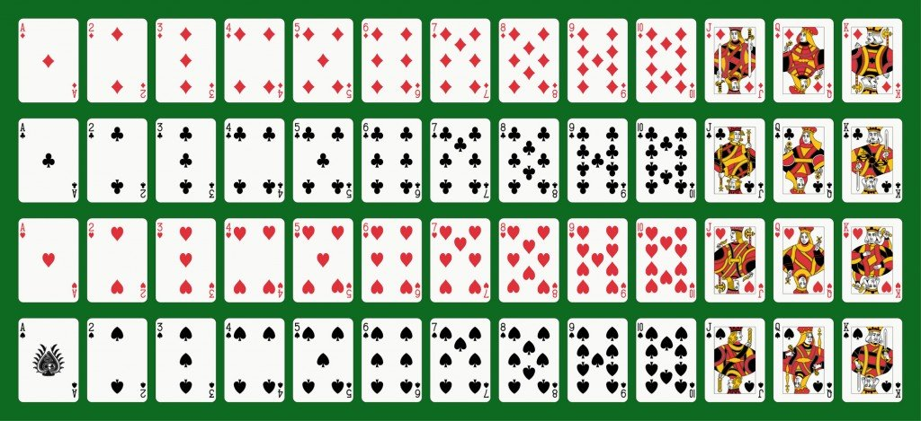

### Solution

PEP 257 docstring convention.

See also NumPy docstring convention.

MyPy

Naming conventions: PEP8

```python
'\u2666'
```

```
'♦'
```

```python
'\u2665'
```

```
'♥'
```

```python
class Card:
    """
    A playing card.

    Parameters
    ----------
    rank: a string {"A", "2", ..., "10", "J", "Q", "K"}
    suit: a string {'♣', '♦', '♥', '♠'}

    """
    SUITS = ['♣', '♦', '♥', '♠']
    RANKS = ['A'] + [str(val) for val in range(2, 11)] + ['J', 'Q', 'K']

    def __init__(self, rank: str, suit: str):
        self._rank = rank
        self._suit = suit

    def is_royal(self) -> bool:
        if self._rank in {'J', 'Q', 'K'}:
            return True
        else:
            return False

    def is_ace(self) -> bool:
        return self._rank == 'A'

    def bj_value(self) -> int:
        if self.is_royal():
            return 10
        elif self.is_ace():
            return 1
        else:
            return int(self._rank)

    def __repr__(self) -> str:
        return f"Card(rank={self._rank}, suit={self._suit})"
```

```python
def test_Card():
    three_of_diamonds = Card('3', '♦')
    assert not three_of_diamonds.is_royal()

    ace_of_spades = Card('A', '♠')
    assert ace_of_spades.bj_value() == 1
```

```python
test_Card()
```

### Extended exercises: simulation

1. Use random.sample() to draw 1 million random “hands” of 3 cards from a standard deck of 52 cards.
2. What proportion of blackjack hands with 3 cards go “bust” (sum of values > 21)?
3. Challenge exercise: Rewrite the answers to questions (4) and (5) to use generators.

```python
deck = []
```

```python
for rank in Card.RANKS:
    for suit in Card.SUITS:
        card = Card(rank, suit)
        deck.append(card)
```

Equivalent:

```python
from itertools import product
```

"Cartesian product"

```python
list(product('AB', 'DE'))
```

```
[('A', 'D'), ('A', 'E'), ('B', 'D'), ('B', 'E')]
```

```python
deck = [Card(rank, suit)
        for (rank, suit) in product(Card.RANKS, Card.SUITS)]
```

```python
assert len(deck) == 52
```

```python
deck
```

```
[Card(rank=A, suit=♣),
 Card(rank=A, suit=♦),
 Card(rank=A, suit=♥),
 Card(rank=A, suit=♠),
 Card(rank=2, suit=♣),
 Card(rank=2, suit=♦),
 Card(rank=2, suit=♥),
 Card(rank=2, suit=♠),
 Card(rank=3, suit=♣),
 Card(rank=3, suit=♦),
 Card(rank=3, suit=♥),
 Card(rank=3, suit=♠),
 Card(rank=4, suit=♣),
 Card(rank=4, suit=♦),
 Card(rank=4, suit=♥),
 Card(rank=4, suit=♠),
 Card(rank=5, suit=♣),
 Card(rank=5, suit=♦),
 Card(rank=5, suit=♥),
 Card(rank=5, suit=♠),
 Card(rank=6, suit=♣),
 Card(rank=6, suit=♦),
 Card(rank=6, suit=♥),
 Card(rank=6, suit=♠),
 Card(rank=7, suit=♣),
 Card(rank=7, suit=♦),
 Card(rank=7, suit=♥),
 Card(rank=7, suit=♠),
 Card(rank=8, suit=♣),
 Card(rank=8, suit=♦),
 Card(rank=8, suit=♥),
 Card(rank=8, suit=♠),
 Card(rank=9, suit=♣),
 Card(rank=9, suit=♦),
 Card(rank=9, suit=♥),
 Card(rank=9, suit=♠),
 Card(rank=10, suit=♣),
 Card(rank=10, suit=♦),
 Card(rank=10, suit=♥),
 Card(rank=10, suit=♠),
 Card(rank=J, suit=♣),
 Card(rank=J, suit=♦),
 Card(rank=J, suit=♥),
 Card(rank=J, suit=♠),
 Card(rank=Q, suit=♣),
 Card(rank=Q, suit=♦),
 Card(rank=Q, suit=♥),
 Card(rank=Q, suit=♠),
 Card(rank=K, suit=♣),
 Card(rank=K, suit=♦),
 Card(rank=K, suit=♥),
 Card(rank=K, suit=♠)]
```

```python
from random import sample
```

```python
hands = [sample(deck, 3) for _ in range(10**6)]
```

Convention: if you don't need a variable, you can replace it with `_`

```python
import sys
sys.version
```

```
'3.8.4 | packaged by conda-forge | (default, Jul 17 2020, 15:16:46) \n[GCC 7.5.0]'
```

```python
# For Python < 3.9:
from __future__ import annotations

def is_bust(hand: list[Card]) -> bool:
    """
    Whether the sum of the values of the given Card objects in Blackjack
    is > 21
    """
    return sum([card.bj_value() for card in hand]) > 21
```

```python
hand = sample(deck, 3)

hand
```

```
[Card(rank=3, suit=♣), Card(rank=10, suit=♣), Card(rank=K, suit=♠)]
```

```python
is_bust(hand)
```

```
True
```

```python
count = 0

for hand in hands:
    if is_bust(hand):
        count += 1

count / len(hands)
```

```
0.377582
```

```python
sum([is_bust(hand) for hand in hands]) / len(hands)
```

```
0.377582
```

```python
from statistics import mean
```

```python
mean([is_bust(hand) for hand in hands])
```

```
0.377582
```

This is compact and readable but wasteful of memory with a concrete list of 1 million True or False values.

Alternative: exact answer: check out `combinations()` in `itertools`.

### Question: when to use dataclasses vs namedtuples vs regular classes?

Data classes are a feature of recent Python versions.

They are supposed to be a helpful way of reducing boilerplate when creating a class.

I find them useful mostly for trivial cases.

```python
# three_of_diamonds == four_or_diamonds
```

They can be readable.

#### Namedtuples here?

Yes: here is fine.

No if you need to mutate internal state.

## Lazy sequences

```python
mean((is_bust(hand) for hand in hands))
```

```
0.377582
```

You get the same answer but this doesn't create a concrete list in memory.

This slightly simpler syntax is supported too:

```python
mean(is_bust(hand) for hand in hands)
```

```
0.377582
```

```python
def my_mean(iterable):
    n = 0
    total = 0
    for thing in iterable:
        total += thing
        n += 1
    return total / n
```

```python
my_mean(is_bust(hand) for hand in hands)
```

```
0.377582
```

### Iterable

Something you can have a `for` loop over.

```python
names = ['Ed', 'Henry', 'Maciej']
```

```python
iterator = iter(names)
```

```python
# Python calls this:
names.__iter__()

# Equivalent to:
list.__iter__(names)
```

```
<list_iterator at 0x7fc2f20ca5b0>
```

The above didn't fail. Therefore `names` is iterable.

Examples of iterable collections:

- list
- set
- dict (keys)
- DataFrame: one column at a time
- NumPy array: one row at a time
- lazy sequences ...

```python
for thing in heights_dict:   # same as heights_dict.keys()
    print(thing)
```

```
Ed
Henry
Maciej
Panos
```

#### Summary: an "iterable" is an object with an `__iter__` method that returns an "iterator".

An "iterator" is something with a `__next__` method

```python
# This simple syntax:
# for a in thing:
#     print(a)
# ... is very similar to this:

iterator = iter(thing)
while True:
    try:
        a = next(iterator)
    except StopIteration:
        break
    print(a)
```

```
P
a
n
o
s
```

### Exercise: define a class `LeapYearSequence(start, end)` whose instances are iterable.

Hint:

- Define `__init__`
- Define `__iter__` as simply returning `self`
- Define `__next__`

(When done in `__next__`, raise a `StopIteration()` exception.

Hint:

```python
from calendar import isleap

isleap(2020)
```

```
True
```

#### Goal

This example code should print all leap years from 2010 to 2030:

```python
for leap_year in LeapYearSequence(2010, 2030):
    print(leap_year)
```

This code should give you a list of all leap years from 2010 to 2030:

```python
leap_years = list(LeapYearSequence(2010, 2030))
```